# Exercicio 1 - Machine Learning - Regressão Logística

Amanda Provetti

Considere o conjunto de dados iris, amplamente conhecido e usado como exemplo em diversos livros de aprendizagem de máquina. Esse conjunto já vem incorporado em diversos pacotes das linguagens R e Python, de acordo com Linguagem R: library(datasets) Linguagem Python: from sklearn import datasets A partir do conjunto de dados carregado capture somente os dados relacionados com a classe virginica, que consiste em uma espécie de uma planta (flor). O objetivo desse exercício é construir um classificador binário a partir de um modelo de regressão logística, permitindo verificar se uma espécie a ser testada é ou não do tipo virginica. Isso significa que um pré-processamento deve ser realizado sobre o dataset iris a fim de obtermos apenas duas classes (e.g., 0 -> não é virginica e 1 -> é virginica). As variáveis explanatórias desse conhecido dataset são: • Petal.Length: comprimento da pétala da flor • Petal.Width: largura da pétala da flor • Sepal.Length: comprimento da sépala da flor • Sepal.Width: largura da sépala da flor

– 1) Realize o pré-processamento necessário para extração dos dados relacionados à classe virginica.

```r
install.packages("varhandle")
install.packages("fastDummies")
library(datasets)
library(varhandle)
library(tidyverse)
library(fastDummies)
library(caret)
```

1. Realize o pré-processamento necessário para extração dos dados relacionados à classe virginica

```r
dataset = iris
```

2. Faça a análise de dados das variáveis explanatórias para o conjunto de dados.

```r
summary(dataset)
```

```
  Sepal.Length    Sepal.Width     Petal.Length    Petal.Width          Species
 Min.   :4.300   Min.   :2.000   Min.   :1.000   Min.   :0.100   setosa    :50
 1st Qu.:5.100   1st Qu.:2.800   1st Qu.:1.600   1st Qu.:0.300   versicolor:50
 Median :5.800   Median :3.000   Median :4.350   Median :1.300   virginica :50
 Mean   :5.843   Mean   :3.057   Mean   :3.758   Mean   :1.199
 3rd Qu.:6.400   3rd Qu.:3.300   3rd Qu.:5.100   3rd Qu.:1.800
 Max.   :7.900   Max.   :4.400   Max.   :6.900   Max.   :2.500
```

```r
all_species <- data.frame(Species = iris$Species)
binary_species <- dummy_cols(all_species, "Species", remove_selected_columns = TRUE)
```

```r
Species <- binary_species %>% select(Species_virginica)

dataset <- data.frame(dataset$Sepal.Length, dataset$Sepal.Width, dataset$Petal.Length, dataset$Petal.Width, Species=Species$Species_virginica)
cols <- c("Species")
dataset[cols] <- lapply(dataset[cols], factor)
```

3. Realize a divisão do conjunto de treino e teste em 90/10.

```r
indices_treinamento <- createDataPartition(dataset$Species, p = 0.9, list = FALSE)
dados_treinamento <-dataset[indices_treinamento,]
dados_teste <- dataset[-indices_treinamento,]
```

4. Para reprodução dos resultados use o set.seed(12)

```r
set.seed(12)
```

5. Forneça visualizações de dispersão e densidades das variáveis explanatórias de treino e as classes.

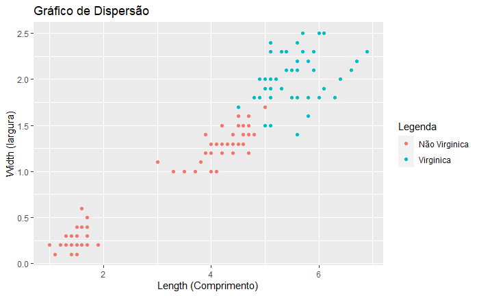

```r
ggplot(dados_treinamento, aes(x = dados_treinamento$dataset.Petal.Length, y = dados_treinamento$dataset.Petal.Width, color=Species)) +
  geom_point() +
  scale_color_discrete(name = "Legenda", labels = c("Não Virginica","Virginica"))+
  ylab('Width (largura)') +
  xlab('Length (Comprimento)') +
  ggtitle("Gráfico de Dispersão")
```

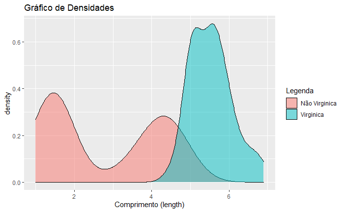

```r
ggplot(data = dados_treinamento, aes(x=dados_treinamento$dataset.Petal.Length, fill= Species)) +
  geom_density(alpha=.5) +
  xlab('Comprimento (length)') +
  scale_fill_discrete(name = "Legenda", labels = c("Não Virginica","Virginica")) +
  ggtitle("Gráfico de Densidades")
```

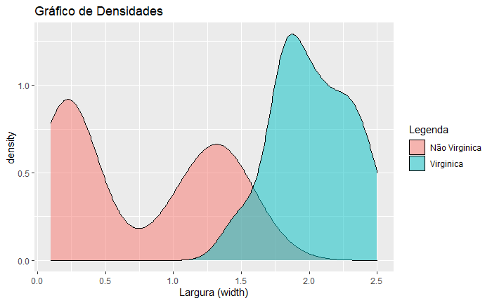

```r
ggplot(data = dados_treinamento, aes(x=dados_treinamento$dataset.Petal.Width, fill= Species)) +
  geom_density(alpha=.5) +
  xlab('Largura (width)') +
  scale_fill_discrete(name = "Legenda", labels = c("Não Virginica","Virginica")) +
  ggtitle("Gráfico de Densidades")
```

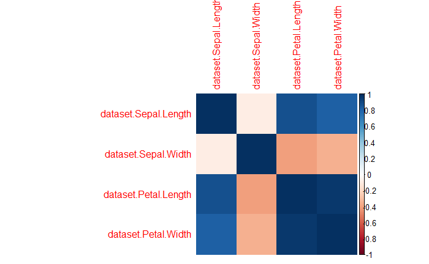

```r
feature_dataframe    = dados_treinamento[,1:4]
matrix_corr_features = cor(feature_dataframe)
corrplot(matrix_corr_features, method = 'color')
```

6. Construa e treine o modelo preditivo de ML baseado em regressão logística

```r
equation <- " Species ~ ."
equation <- as.formula(equation)
```

```r
modelo_ML_logistic <- glm(equation, data = dados_treinamento, family = 'binomial')
```

7. Faça a síntese do modelo e interprete os seus resultados

```r
summary(modelo_ML_logistic)
```

```
Call:
glm(formula = equation, family = "binomial", data = dados_treinamento)

Deviance Residuals:
       Min          1Q      Median          3Q         Max
-1.893e-04  -2.100e-08  -2.100e-08   2.100e-08   1.910e-04

Coefficients:
                      Estimate Std. Error z value Pr(>|z|)
(Intercept)            -538.18  107640.43  -0.005    0.996
dataset.Sepal.Length    -67.05   19930.85  -0.003    0.997
dataset.Sepal.Width    -139.43   21000.05  -0.007    0.995
dataset.Petal.Length    214.16   34161.50   0.006    0.995
dataset.Petal.Width     185.63   34135.10   0.005    0.996

(Dispersion parameter for binomial family taken to be 1)

    Null deviance: 1.7186e+02  on 134  degrees of freedom
Residual deviance: 1.3423e-07  on 130  degrees of freedom
AIC: 10

Number of Fisher Scoring iterations: 25
```

8. Encontre as variáveis explanatórias mais relevantes para o modelo.

```r
modelo_ML_logistic_2 <- glm(Species ~ dataset.Petal.Width + dataset.Petal.Length, data = dados_treinamento, family = 'binomial')
```

```
glm.fit: probabilidades ajustadas numericamente 0 ou 1 ocorreu
```

```r
summary(modelo_ML_logistic_2)
```

```
Call:
glm(formula = Species ~ dataset.Petal.Width + dataset.Petal.Length,
    family = "binomial", data = dados_treinamento)

Deviance Residuals:
     Min        1Q    Median        3Q       Max
-1.92956  -0.00813   0.00000   0.00424   1.98154

Coefficients:
                     Estimate Std. Error z value Pr(>|z|)
(Intercept)           -47.535     15.288  -3.109  0.00188 **
dataset.Petal.Width     8.342      4.042   2.064  0.03902 *
dataset.Petal.Length    7.009      3.013   2.326  0.02000 *
---
Signif. codes:  0 ‘***’ 0.001 ‘**’ 0.01 ‘*’ 0.05 ‘.’ 0.1 ‘ ’ 1

(Dispersion parameter for binomial family taken to be 1)

    Null deviance: 171.859  on 134  degrees of freedom
Residual deviance:  15.913  on 132  degrees of freedom
AIC: 21.913

Number of Fisher Scoring iterations: 10
```

9. Faça as predições para os dados de teste e avalie os resultados

```r
previsao_teste <- predict(modelo_ML_logistic_2, dados_teste, type="response")
previsao_teste <- round(as.numeric(previsao_teste))
previsao_teste <- as.factor(previsao_teste)

dados_teste_fatores = as.factor(dados_teste$Species)
previsao_teste_data <- data.frame(previsao_teste, dados_teste_fatores)
confusionMatrix(data = previsao_teste, reference = dados_teste_fatores, positive = "1")
```

```
Confusion Matrix and Statistics

          Reference
Prediction 0 1
         0 9 0
         1 1 5

               Accuracy : 0.9333
                 95% CI : (0.6805, 0.9983)
    No Information Rate : 0.6667
    P-Value [Acc > NIR] : 0.01941

                  Kappa : 0.8571

 Mcnemar's Test P-Value : 1.00000

            Sensitivity : 1.0000
            Specificity : 0.9000
         Pos Pred Value : 0.8333
         Neg Pred Value : 1.0000
             Prevalence : 0.3333
         Detection Rate : 0.3333
   Detection Prevalence : 0.4000
      Balanced Accuracy : 0.9500

       'Positive' Class : 1
```

10. A partir dos novos dados de entrada colocados abaixo, realize as classificações com o modelo

```r
flor1 <- data.frame(dataset.Sepal.Length=6.4, dataset.Sepal.Width=2.8, dataset.Petal.Length=4.6, dataset.Petal.Width=1.8)
flor2 <- data.frame(dataset.Sepal.Length=6.3, dataset.Sepal.Width=2.5, dataset.Petal.Length=4.1, dataset.Petal.Width=1.7)

pred_flor1 <- predict(modelo_ML_logistic, flor1, type = 'response')
pred_flor2 <- predict(modelo_ML_logistic, flor2, type = 'response')
pred_flor1
```

```
           1
2.220446e-16
```

```r
pred_flor2
```

```
           1
2.220446e-16
```